# Assignment 4

# 1 Read the NYC Pluto data about land value from in Manhattan from https://query.data.world/s/WuYif0WbZCxzOLjLh95TY9rK--Tw64 (Links to an external site.)Links to an external site.. Ignore any warnings caused by using read_csv if you use that function. The data contain characteristic information about individual lots in Manhattan. We want to model the value of lots (TotalValue) as a function of its characteristics.

```r
# land data set
land <- readRDS(here::here('data', 'manhattan_Train.rds'))
```

## 1.1 First, generate summary statistics of variables you find interesting and build plots to help you explore the data. Choose the type of plot that makes the most sense to you.

```r
# choosing variable for model
land1 <- lm(TotalValue ~ LotArea + NumFloors + ZoneDist1 + PolicePrct + Built + Class, data=land)
summary(land1)
```

```
##
## Call:
## lm(formula = TotalValue ~ LotArea + NumFloors + ZoneDist1 + PolicePrct +
##     Built + Class, data = land)
##
## Residuals:
##       Min        1Q    Median        3Q       Max
## -42531650   -741951   -130582    369626  18347064
##
## Coefficients:
##                              Estimate Std. Error t value Pr(>|t|)
## (Intercept)                 1.154e+04  2.043e+05   0.056 0.954944
## LotArea                     3.202e+01  6.171e-01  51.881  < 2e-16 ***
## NumFloors                   4.701e+05  4.033e+03 116.560  < 2e-16 ***
## ZoneDist1Manufacturing      9.566e+04  5.616e+04   1.703 0.088497 .
## ZoneDist1Mixed Residential -3.121e+05  3.527e+05  -0.885 0.376267
## ZoneDist1Park               5.849e+05  2.427e+05   2.410 0.015947 *
## ZoneDist1Residential       -4.993e+05  3.135e+04 -15.926  < 2e-16 ***
## PolicePrct                 -1.448e+04  1.331e+03 -10.878  < 2e-16 ***
## Built10s                   -6.391e+05  1.456e+05  -4.388 1.15e-05 ***
## Built18th Century          -4.078e+05  7.463e+04  -5.464 4.68e-08 ***
## Built60s                    1.393e+06  1.092e+05  12.763  < 2e-16 ***
## Built70s                    1.358e+05  1.462e+05   0.929 0.352979
## Built80s                    3.795e+05  1.291e+05   2.940 0.003284 **
## Built90s                    8.852e+05  1.394e+05   6.349 2.20e-10 ***
## BuiltPostwar                6.139e+05  9.420e+04   6.516 7.31e-11 ***
## BuiltPrewar                 2.232e+05  7.928e+04   2.815 0.004874 **
## BuiltUnknown                8.643e+05  1.300e+05   6.648 3.01e-11 ***
## ClassAutomotive             2.502e+05  2.131e+05   1.174 0.240338
## ClassCondo                  1.017e+06  1.945e+05   5.227 1.73e-07 ***
## ClassEducation              2.952e+06  2.115e+05  13.960  < 2e-16 ***
## ClassElevator Apartment     5.233e+05  1.902e+05   2.752 0.005924 **
## ClassGovernment             1.078e+06  2.935e+05   3.671 0.000242 ***
## ClassHealth                 1.640e+06  2.416e+05   6.788 1.16e-11 ***
## ClassHotel                  2.042e+06  2.183e+05   9.351  < 2e-16 ***
## ClassIndustrial            -7.307e+05  4.241e+05  -1.723 0.084904 .
## ClassLoft                  -1.074e+05  2.116e+05  -0.507 0.611824
## ClassMisc                   1.549e+06  2.945e+05   5.260 1.45e-07 ***
## ClassMixed                 -7.895e+05  1.925e+05  -4.101 4.13e-05 ***
## ClassOffice                 1.237e+06  1.957e+05   6.318 2.69e-10 ***
## ClassOutdoor               -3.234e+05  2.851e+05  -1.134 0.256707
## ClassPublic                 1.399e+06  2.498e+05   5.603 2.13e-08 ***
## ClassReligious              5.409e+05  2.020e+05   2.678 0.007401 **
## ClassRetail                 7.013e+05  1.936e+05   3.622 0.000293 ***
## ClassSingle Family         -4.710e+05  1.937e+05  -2.432 0.015038 *
## ClassTheatre                1.260e+06  2.859e+05   4.407 1.05e-05 ***
## ClassTransport             -3.001e+05  3.156e+05  -0.951 0.341582
## ClassTwo Family            -3.139e+05  1.948e+05  -1.612 0.107073
## ClassUtility                3.377e+05  1.462e+06   0.231 0.817319
## ClassVacant                 3.443e+05  2.274e+05   1.514 0.129952
## ClassWalk Up Apartment     -5.656e+05  1.880e+05  -3.008 0.002628 **
## ClassWarehouse              2.022e+05  2.560e+05   0.790 0.429631
## ---
## Signif. codes:  0 '***' 0.001 '**' 0.01 '*' 0.05 '.' 0.1 ' ' 1
##
## Residual standard error: 2045000 on 32209 degrees of freedom
## Multiple R-squared:  0.593,  Adjusted R-squared:  0.5925
## F-statistic:  1173 on 40 and 32209 DF,  p-value: < 2.2e-16
```

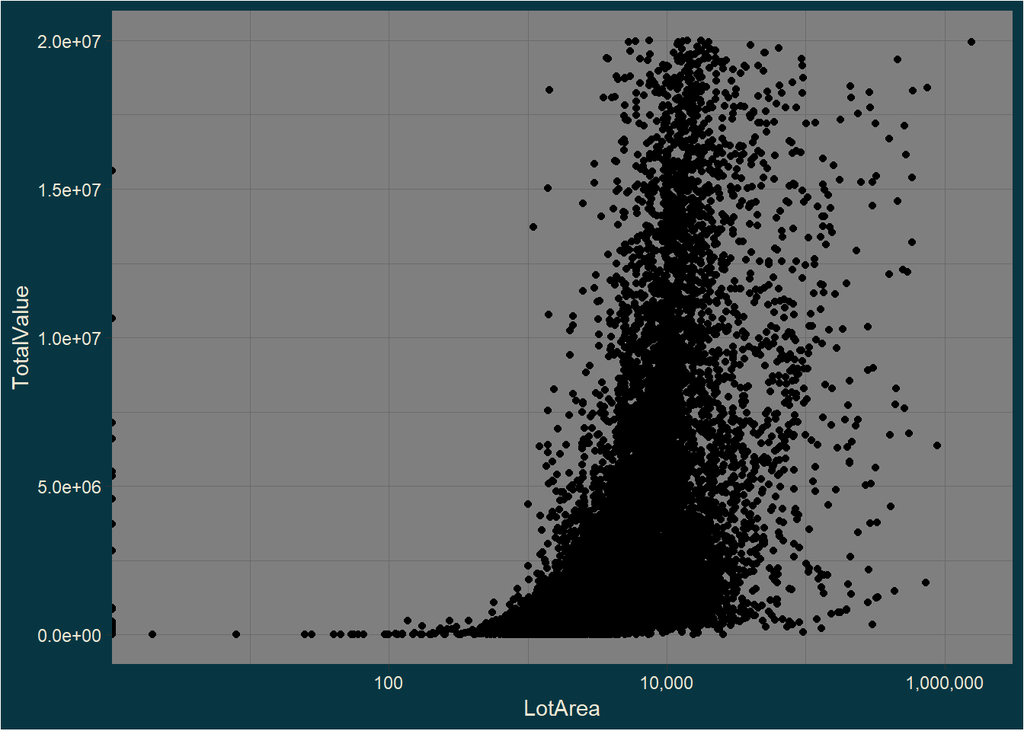

```r
library(ggplot2)
library(ggthemes)
theme_solarized_dark <- function() {
    theme_dark() +
        theme(
            plot.background = element_rect(fill = "#073642"),
            axis.text = element_text(color = '#eee8d5'),
            text = element_text(color = '#eee8d5'))
}

# plot x and y
ggplot(land1, aes(x=LotArea, y=TotalValue)) +
        geom_point() +
        scale_x_log10(labels = scales::comma) +
        theme_solarized_dark()
```

## 1.2 Next, regress TotalValue against FireService, LotArea, LotFront and HistoricDistrict. Visualize with a coefficient plot and interpret each coeﬃcient in your own words.

```r
land2 <- lm(TotalValue ~ FireService + LotArea + LotFront + HistoricDistrict, data=land)
summary(land2)
```

```
##
## Call:
## lm(formula = TotalValue ~ FireService + LotArea + LotFront +
##     HistoricDistrict, data = land)
##
## Residuals:
##       Min        1Q    Median        3Q       Max
## -82411636  -1179602   -890682   -153579  18101224
##
## Coefficients:
##                       Estimate Std. Error t value Pr(>|t|)
## (Intercept)          1.047e+06  2.749e+04  38.093  < 2e-16 ***
## FireServiceLadder   -1.764e+05  3.274e+04  -5.390  7.1e-08 ***
## FireServiceSquad    -4.163e+05  1.467e+05  -2.837  0.00455 **
## LotArea              1.772e+01  9.204e-01  19.254  < 2e-16 ***
## LotFront             1.656e+04  2.888e+02  57.332  < 2e-16 ***
## HistoricDistrictYes  1.022e+04  3.755e+04   0.272  0.78553
## ---
## Signif. codes:  0 '***' 0.001 '**' 0.01 '*' 0.05 '.' 0.1 ' ' 1
##
## Residual standard error: 2907000 on 32244 degrees of freedom
## Multiple R-squared:  0.1765, Adjusted R-squared:  0.1764
## F-statistic:  1382 on 5 and 32244 DF,  p-value: < 2.2e-16
```

```r
# The value of the property goes down quite a bit if near a fire station, even more so if near a fire squad unit
# Value increases with both lot size and fascade size, as well as if in a Historic District, although not as much
```

# 2 Continue modeling the Pluto data until the BIC of the model is below 1,040,000. Show a coefficient plot of the final model. Then display a coefficient plot, with multiplot, showing both the previous model and this model.

```r
BIC(land1, land2)
```

```
##       df     BIC
## land1 42 1029157
## land2  7 1051521
```

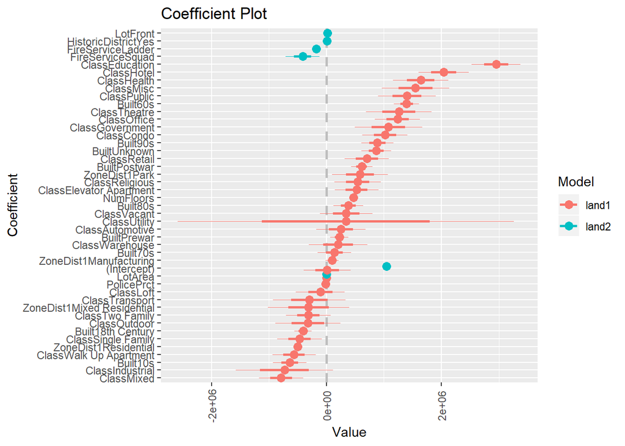

```r
# Got it good on first try!
# graph it
library(coefplot)
multiplot(land1, land2, sort='magnitude')
```

# 3 Load the orings dataset from the DAAG package. The dataset contains information on characteristics of space shuttle launches in the early 1980s, and the number and type of 45 O-ring failures. Investigate whether the temperature at launch has an impact on the probability of O-ring failure using binary (logistic) regression.

```r
install.packages('DAAG')
```

```
## Error in contrib.url(repos, "source"): trying to use CRAN without setting a mirror
```

```r
data(orings, package='DAAG')
```

## 3.1 First, use mutate (or some other method) to create a binary variable indicating whether there is any erosion (Erosion) or blow-by (Blowby).

```r
library(dplyr)
orings1 <- orings %>%
    mutate(EorB=ifelse(Blowby > 0 | Erosion > 0, TRUE, FALSE))
head(orings1)
```

```
##   Temperature Erosion Blowby Total  EorB
## 1          53       3      2     5  TRUE
## 2          57       1      0     1  TRUE
## 3          58       1      0     1  TRUE
## 4          63       1      0     1  TRUE
## 5          66       0      0     0 FALSE
## 6          67       0      0     0 FALSE
```

## 3.2 Next, train a binary regression where this new variable is the response and Temperature is a predictor. Does Temperature impact the risk of o-ring failure?

```r
orings2 <- glm(EorB ~ Temperature,
               data=orings1,
               family=binomial)
summary(orings2)
```

```
##
## Call:
## glm(formula = EorB ~ Temperature, family = binomial, data = orings1)
##
## Deviance Residuals:
##     Min       1Q   Median       3Q      Max
## -1.0611  -0.7613  -0.3783   0.4524   2.2175
##
## Coefficients:
##             Estimate Std. Error z value Pr(>|z|)
## (Intercept)  15.0429     7.3786   2.039   0.0415 *
## Temperature  -0.2322     0.1082  -2.145   0.0320 *
## ---
## Signif. codes:  0 '***' 0.001 '**' 0.01 '*' 0.05 '.' 0.1 ' ' 1
##
## (Dispersion parameter for binomial family taken to be 1)
##
##     Null deviance: 28.267  on 22  degrees of freedom
## Residual deviance: 20.315  on 21  degrees of freedom
## AIC: 24.315
##
## Number of Fisher Scoring iterations: 5
```

```r
# The colder it gets, the greater the risk of O-ring failure
```

# 4 Load the DoctorAUS dataset from the Ecdat package. Use Poisson regression to model the number of doctor visits (doctorco).

## 4.1 Report the BIC and display a coefficient plot on the original scale by setting the trans argument of coefplot to the appropriate inverse function. This requires reading section 20.2.

```r
data(DoctorAUS, package='Ecdat')
DoctorAUS1 <- glm(doctorco ~ sex + age + income + insurance + illness,
                 family='poisson', data=DoctorAUS)
BIC(DoctorAUS1)
```

```
## [1] 7468.676
```

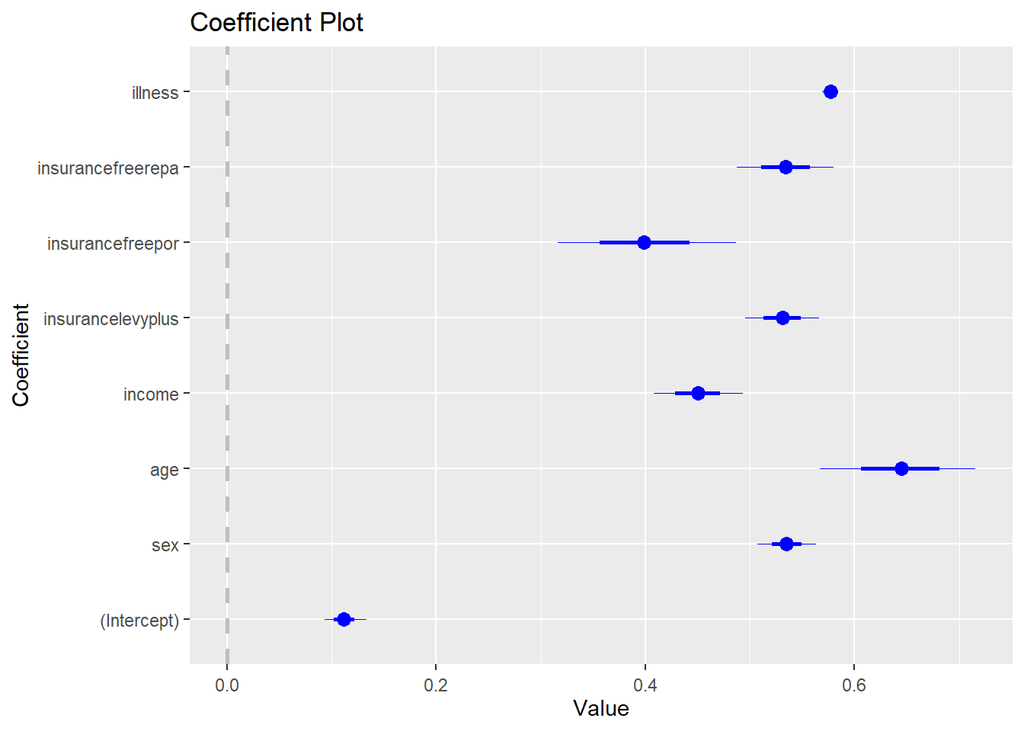

```r
coefplot(DoctorAUS1, trans=invlogit)
```

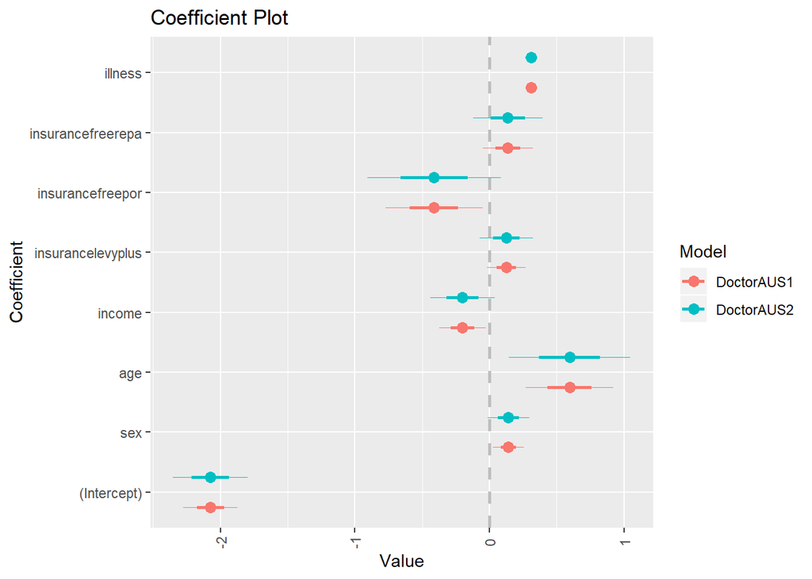

```r
DoctorAUS2 <- glm(doctorco ~ sex + age + income + insurance + illness,
                 family='quasipoisson', data=DoctorAUS)
multiplot(DoctorAUS1, DoctorAUS2)
```